# Analyzing [Ford GoBike System Data]

## Part V - Bivariate Exploration

Explore the dataset by user type to the analysis.

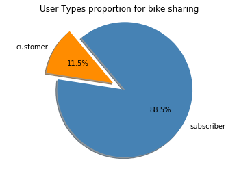

```python
# plotting graph of user type

labels = ['customer', 'subscriber']
color = ['darkorange', 'steelblue']
explode = (0.1, 0.1)
plt.pie([customer_prop, subscriber_prop],explode=explode, labels=labels, colors=color,
       autopct='%1.1f%%', shadow=True, startangle=130);
plt.axis('equal')
plt.title('User Types proportion for bike sharing', fontsize = 12);
```

As we can see, customers are contributing roughly for 12%. However, major portion is of subscribers.

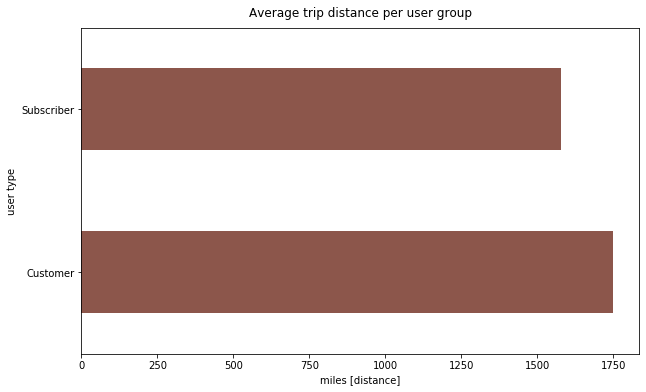

```python
# Average Trip distance of user type
df.groupby('user_type')['distance'].mean().plot(y = user_distance,
                                                kind='barh',
                                                color=base_color,
                                                figsize=(10,6))
plt.title('Average trip distance per user group', fontsize=12, y=1.015)
plt.ylabel('user type')
plt.xlabel('miles [distance]');
```

## Part VI - Multivariate Exploration

Explore the dataset by adding gender to the customer type and check the hourly distribution of bike rides during weekdays for customers and subscribers.

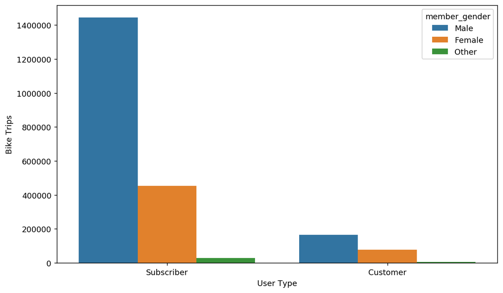

```python
plt.figure(figsize = (10,6), dpi=130)

g = sns.countplot(data=df, x="user_type", hue="member_gender",
                  order=df.user_type.value_counts().index)
g.set_xlabel('User Type')
g.set_ylabel('Bike Trips');
```

In general, males are using it most in both the cases.

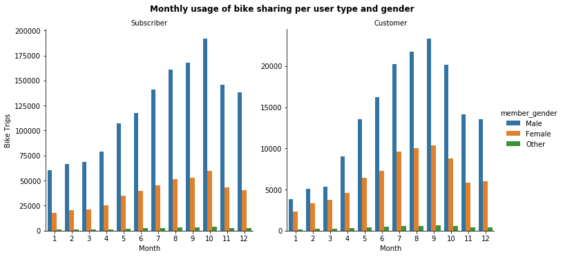

```python
# Monthly usage of bikes per user type and gender
plt.figure(figsize=(12,8), dpi=130)
a = sns.catplot(data=df, x='start_month', col="user_type", hue="member_gender", kind='count', sharey = False)
a.fig.suptitle('Monthly usage of bike sharing per user type and gender', y=1.03, fontsize=12, fontweight='semibold')
a.set_axis_labels('Month', 'Bike Trips')
a.set_titles("{col_name}");
```

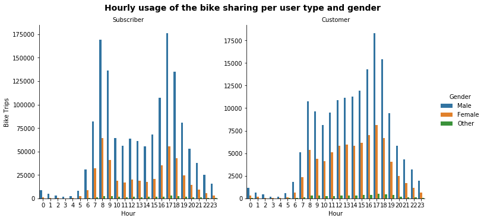

```python
# hourly usage of the bike sharing per user type and gender
plt.figure(figsize=(12,10), dpi=130)
g = sns.catplot(data=df, x='start_hour',
                col="user_type", hue='member_gender',
                kind='count', sharey = False)
g.set_axis_labels("Hour", "Bike Trips")
g._legend.set_title('Gender')
g.set_titles("{col_name}")
g.fig.suptitle('Hourly usage of the bike sharing per user type and gender', y=1.03, fontsize=14, fontweight='semibold');
```

During the day, both males and females use the system the same way: between 8am -9am and 5pm - 6pm